# Week 11 Assignment

Cheryl Bowersox

Friday, April 24, 2015

# Heart Rate

Evaluating the model maxHR = 220 - age for given data

```r
library(ggplot2)
# data
age <- c(18,23,25,35,65, 54, 34, 56, 72, 19, 23, 42, 18, 39, 37)
maxHR <-
  c(202,186,187, 180, 156, 169, 174, 172, 153, 199, 193, 174, 198, 183,178)
calcmaxHR <- 220 - age

fit <- lm(maxHR ~ age)
summary(fit)
```

```
##
## Call:
## lm(formula = maxHR ~ age)
##
## Residuals:
##     Min      1Q  Median      3Q     Max
## -8.9258 -2.5383  0.3879  3.1867  6.6242
##
## Coefficients:
##              Estimate Std. Error t value Pr(>|t|)
## (Intercept) 210.04846    2.86694   73.27  < 2e-16 ***
## age          -0.79773    0.06996  -11.40 3.85e-08 ***
## ---
## Signif. codes:  0 '***' 0.001 '**' 0.01 '*' 0.05 '.' 0.1 ' ' 1
##
## Residual standard error: 4.578 on 13 degrees of freedom
## Multiple R-squared:  0.9091, Adjusted R-squared:  0.9021
## F-statistic:   130 on 1 and 13 DF,  p-value: 3.848e-08
```

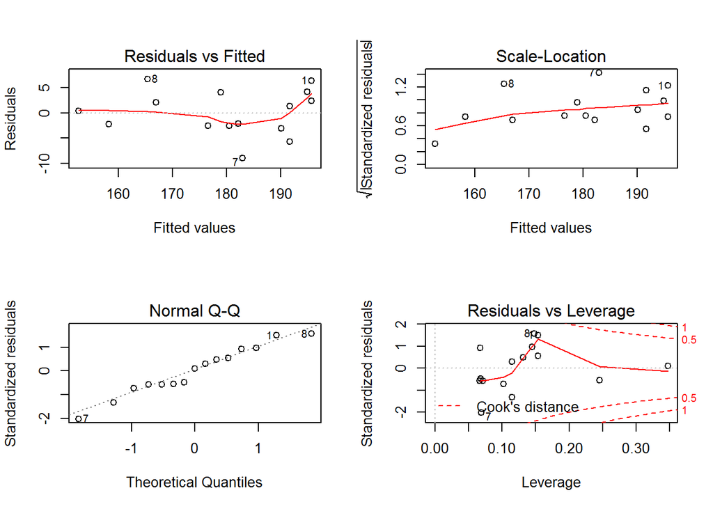

```r
yhat <- fitted(fit)

# plots of fit
layout(matrix(c(1,2,3,4),2,2)) # optional 4 graphs/page
plot(fit)
```

```r
b1 <- summary(fit)[4]$coefficients[2,1]
b0 <- summary(fit)[4]$coefficients[1,1]
p1 <- summary(fit)[4]$coefficients[2,4]
p0 <- summary(fit)[4]$coefficients[1,4]
df <- data.frame(cbind(age,maxHR,yhat, calcmaxHR))
```

The linear model obtained from the regression is $maxHR = -0.7977266 \times age + 210.0484584$

Both the age coefficient -0.7977266 and the intercept value 210.0484584 have a small p-values of 3.847986510^{-8} and 2.12407410^{-18} indicating they are both significant in modeling the dependent variable, with a confidence level greater than 99%.

The model calculated from the sample is fairly close to the assumed model.

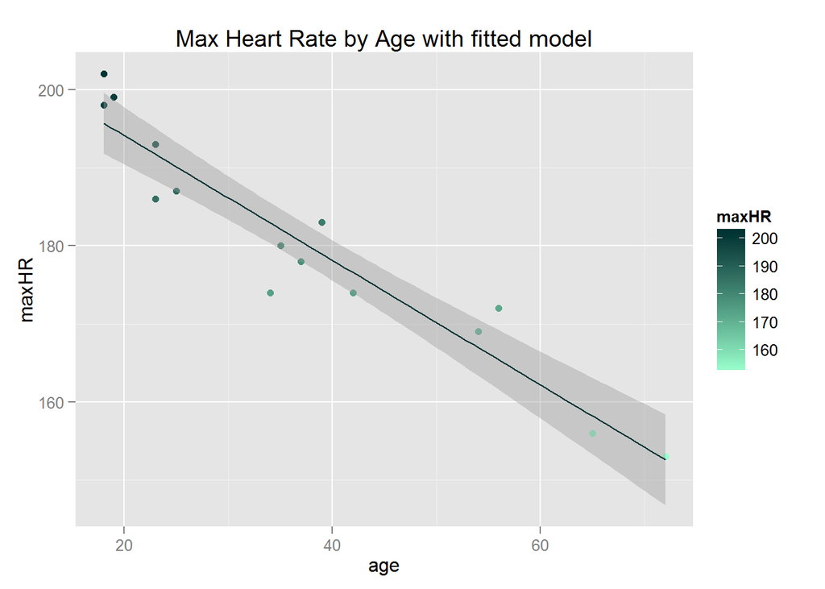

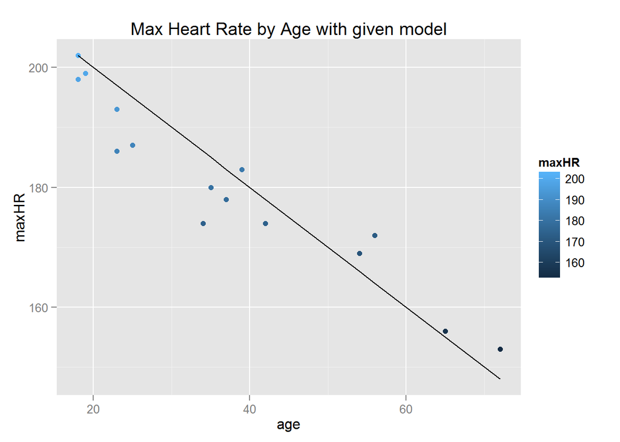